# Creating images with R

with a little bit of magick

Rachel Zheng

2024-03-12

```css
@import url('https://fonts.googleapis.com/css2?family=Madimi+One&family=Open+Sans:ital,wght@0,300..800;1,300..800&display=swap');

body {
  font-family: 'Open Sans', sans-serif;
}

p {
  font-family: 'Open Sans', sans-serif;
  font-size: 17px;
  font-style: italic;
}

h2 {
  font-family: 'Open Sans', sans-serif;
  font-style: italic;
  background-color: rgba(110, 188, 145, 0.6);
}

h4 {
  font-style: italic;
}
```

## Project requirements

I achieved the GitHub requirements for this project by following the methods taught in class. The project repository can be found at [here](https://github.com/r574-rachel/stats220) or Copy link: https://github.com/r574-rachel/stats220. I also deployed the GitHub Pages, which can be accessed [here](https://r574-rachel.github.io/stats220/) or Copy link: https://r574-rachel.github.io/stats220/. The README.md file in the repository provides a brief overview for anyone visiting.

In the screenshot below:

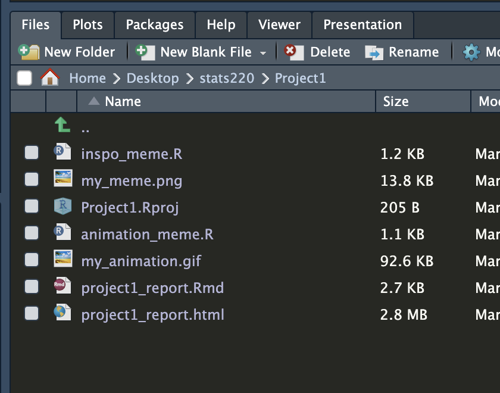

All project files and images meet the project requirements.

## My meme

[figure not shown]

```r
#create first image & resize
first_img <- image_read("https://i.pinimg.com/564x/12/ff/86/12ff860555b5adf7bbbb5134bfa8e7d0.jpg") %>%
  image_resize("200x200")

#create first text
first_text <- image_blank(width = 219, height = 180, color = "#000000") %>%
  image_annotate(text = "MEME",
                 color = "#FFFFFF",
                 size = 30,
                 font = "Impact",
                 gravity = "center")

#combine two top images
top_imgs <- image_append(c(first_img, first_text))

#create second image & resize
second_img <- image_read("https://i.pinimg.com/564x/37/07/47/3707478a84452fac00aa75a24796ddf0.jpg") %>%
  image_resize("200x200")

#create second text
second_text <- second_img %>%
  image_annotate(text = "SO ???",
                 color = "#FFFFFF",
                 size = 30,
                 font = "Impact",
                 location = "+20+50")

#create third image & resize
third_img <- image_read("https://i.pinimg.com/564x/d5/bb/fa/d5bbfa2938352c05371691663432cffe.jpg") %>%
  image_resize("219x219")

#combine two bottom images
bottom_imgs <- image_append(c(second_text, third_img))

#add all the images together
combine_imgs <- c(top_imgs, bottom_imgs) %>%
  image_append(stack = TRUE) %>%
  image_scale(300)

#save image
image_write(combine_imgs, "my_meme.png")
```

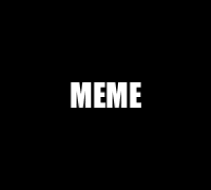

```r
#create first text
first_text <- image_blank(width = 200, height = 180, color = "#000000") %>%
  image_annotate(text = "MEME",
                 color = "#FFFFFF",
                 size = 30,
                 font = "Impact",
                 gravity = "center")

#create first image & resize
first_img <- image_read("https://i.pinimg.com/564x/12/ff/86/12ff860555b5adf7bbbb5134bfa8e7d0.jpg") %>%
  image_resize("200x200")

#create text add to second image
second_text <- image_read("https://i.pinimg.com/564x/37/07/47/3707478a84452fac00aa75a24796ddf0.jpg") %>%
  image_resize("200x200")

#create second image & resize
second_img <- second_text %>%
  image_annotate(text = "SO ???",
                 color = "#FFFFFF",
                 size = 30,
                 font = "Impact",
                 location = "+20+50")

#create third image & resize
third_img <- image_read("https://i.pinimg.com/564x/d5/bb/fa/d5bbfa2938352c05371691663432cffe.jpg") %>%
  image_resize("200x200")


#add all the images together
combine_imgs <- c(first_text, first_img, second_img, third_img) %>%
  image_scale(300)

#make the image a gif type
animated_img_gif <- image_animate(combine_imgs, fps = 2)
animated_img_gif

#save image
image_write(animated_img_gif, "my_animation.gif")
```

## Learning reflection

#### Important idea:

- *Learned how to use R language to stitch different images into one PNG/GIF image at my desired size.*
- *Learned how to use CSS to style web pages.*

I hope that with more learning, I can become proficient in using R language to import, organize and visual data.